# 지급여력제도에 관하여

내재가치평가, IFRS17, 지급여력제도

sonsungman https://sonsungman.github.io/SKKU-Preditive.m/  
10-09-2021

### 목차를 통한 이해

#### 1장

보험회사의 가치평가의 역사를 다루는데 각 제도 EV, 국제회계기준, 지급여력제도(Sol2, ICS, K-ICS) 별로 들여다 본다.

#### 2장

자산과 부채의 가치평가에 대해 다룬다. 평가 원칙과 주로 보험부채의 평가 단위 및 평가에 대해 이야기한다.

#### 3장

지급여력제도에 대해 알아본다. 특히 표준모형과 내부모형에 대한 논의를 볼 수 있어 좋다.

#### 4장

손익 및 변동성 분석으로서 EV MOVE 분석과 IFRS 손익을 구분한다. 몹시 흥미롭다.

#### 5장

제도변화에 따른 자본관리를 다룬다. 핵심은 지급여력제도와 각 보험사들의 자본관리전략이 결부된다는 것.두번째로 경영관리에서 신상품 수익성관리와 ALM(헷징, 공동재보험)을 다룬다.

#### 부록

k-ICS할인율 산출 방법론, LLP, TVOG 산출방법, ESG(환경 사회 거버넌스가 아니다 ^^), PCA(SOL2의 금리리스크 산출에 사용되는 머신러닝 방법론), DNS와 AFNS 까지

### 만찬

읽을 거리가 너무 많고 보험산업의 넓이와 깊이를 보여주는 보고서이며 각 주제를 충분히 음미하며 공부해가는 것이 전문성을 갖춘 계리사가 되는 지름길이라 믿는다. 후에 보고서에 제시된 참고문헌에 해당하는 1차 자료들을 직접 찾아 보는 것이 필요하다 생각한다.

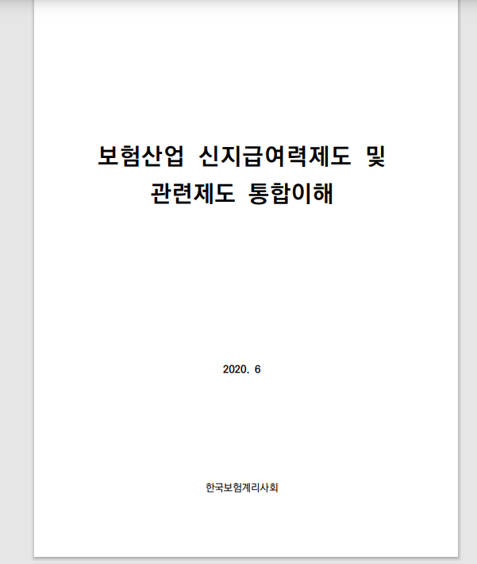

Figure 1: 참고 자료

[figure not shown]

Figure 2: 참고 자료

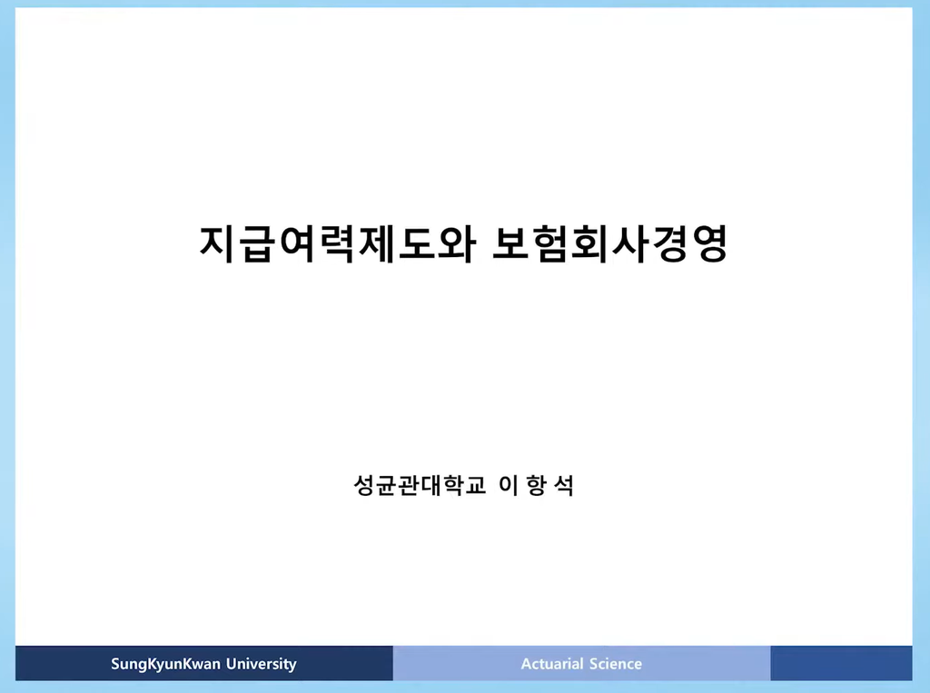

Figure 3: 참고 자료